# Stochastic Simulations

Shen Cheng

2026-11-13

# Drug X

- Drug X is a small molecule drug under early-phase clinical investigation to treat Disease Y in pediatric patients (age 2-18 years).
- An phase-I single ascending dose (SAD) clinical study has been completed to investigate the PK of drug X, with 50 patients receiving 1, 2, 5, 10 and 20 mg dose of drug X.
- A population PK model was developed using these PK data (`./wk10/model/hwwk6.mod`).
- Some efficacy related endpoints were also collected and the clinical team are interested in exploring exposure-response relationships.

# Exercise 1: Stochastic Simulation

- The study team is now designing a Phase 2 proof of concept (POC) study, which they plan to use a twice daily dose (BID) dosing. They want to understand what dosage levels are appropriate to test.
- Preclinical study shows:
  - IC90 of drug X is **1 ug/L**.
  - Drug X concentration above **15 ug/L** is associated with dose-limit toxicity.

## Exercise 1: Question

Considering steady-state is achieved after 4 days with BID dosing. The study team is wondering:

- At what dose levels can we achieve a steady-state Cmin > 1 ug/L in > 80% patients.
- At what dose levels can we maintain a steady-state Cmax > 15 ug/L in < 10% patients.

## Workflow-Stochastic Simulations

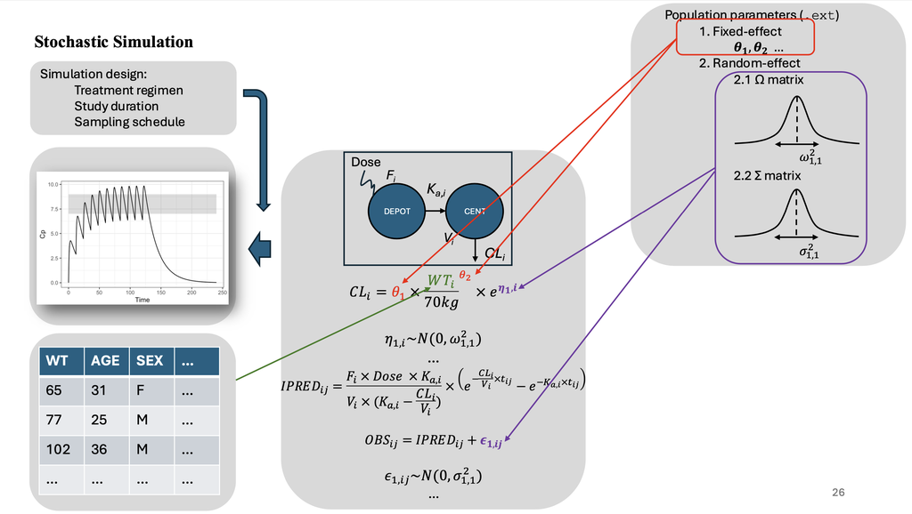

## Workflow-Stochastic Simulations

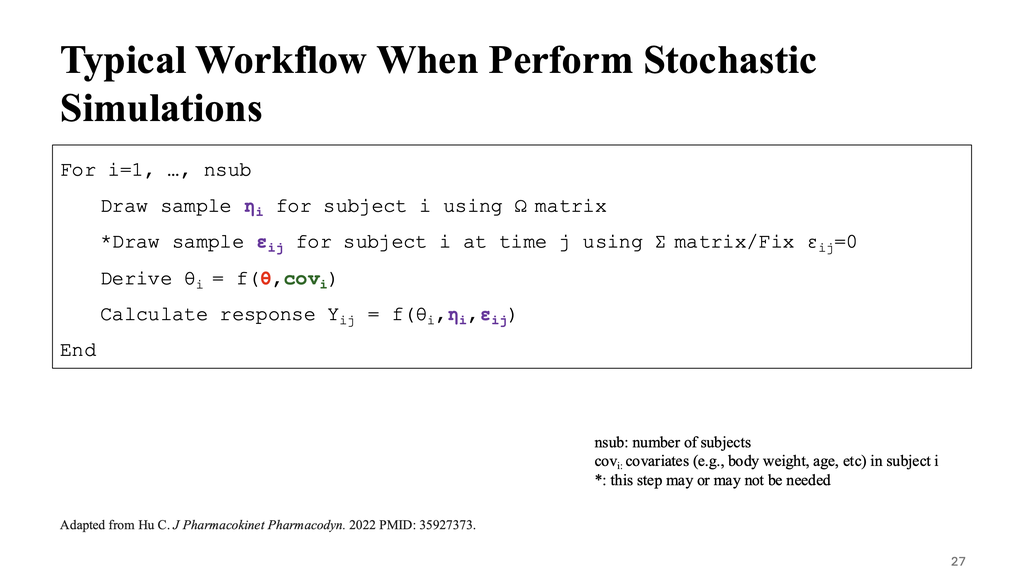

## Hands-on Session: Exercise 1

**Files:**

- `wk10/model/hwwk6.mod`: `mrgsolve` model for Drug X.
- `wk10/ex1.R`: `R` script to implement simulation.
- `wk10/data/pop.csv`: population covariate for simulation.

**Implementation notes:**

- Don’t need residual variability in simulation (`mod <- mod %>% zero_re(sigma)`).
- Use `wk10/data/pop.csv` for population covariates.
- Use `addl` and `ii` to implement multiple dosing (e.g., BID).
- Weight-based dosing.
- Need to have `rate=-2` to enable the use of dosing duration (`D1`) in the model.

## Hands-on Session: Exercise 1

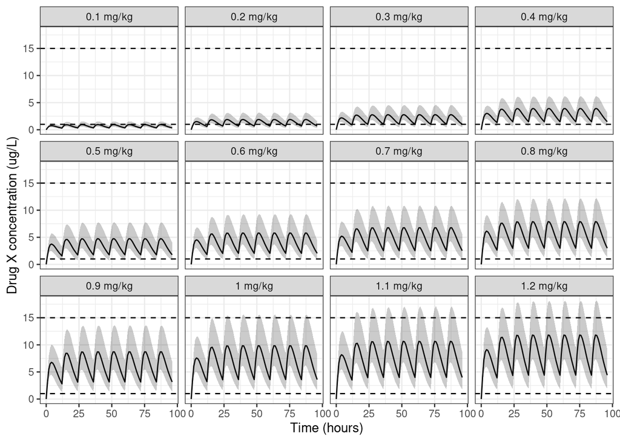

## Hands-on Session: Exercise 1 Cmin

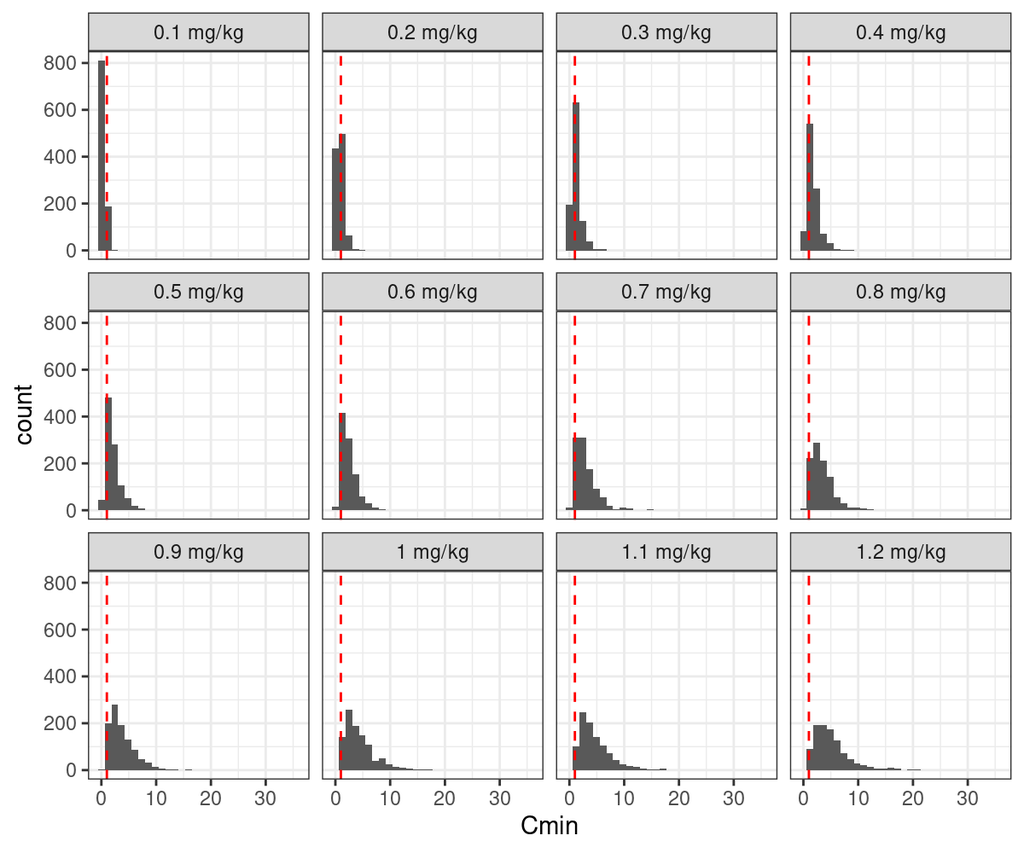

## Hands-on Session: Exercise 1 Cmin

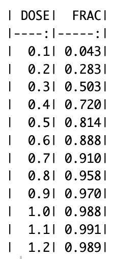

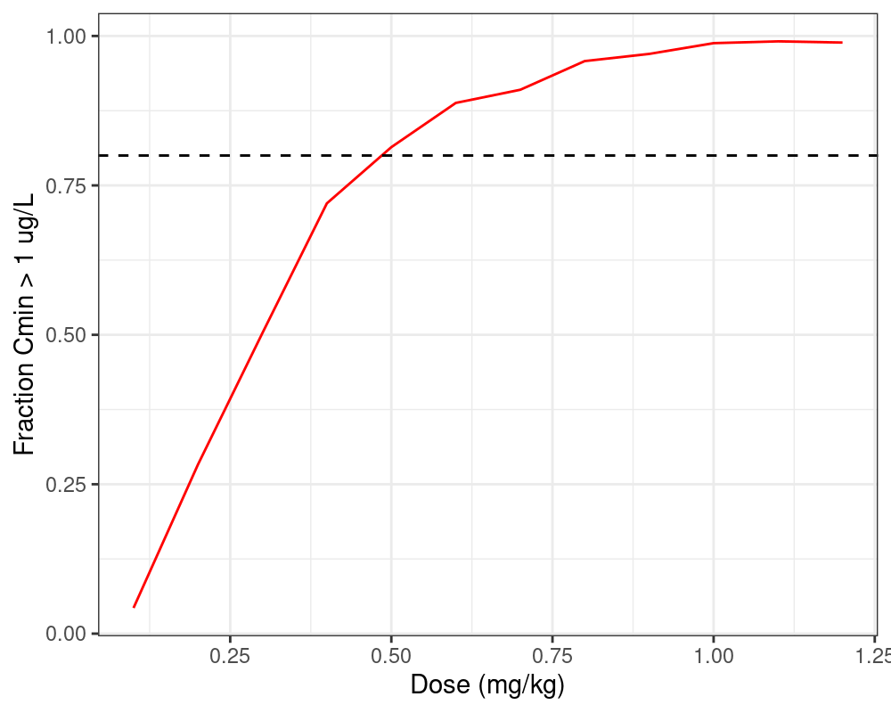

## Hands-on Session: Exercise 1 Cmax

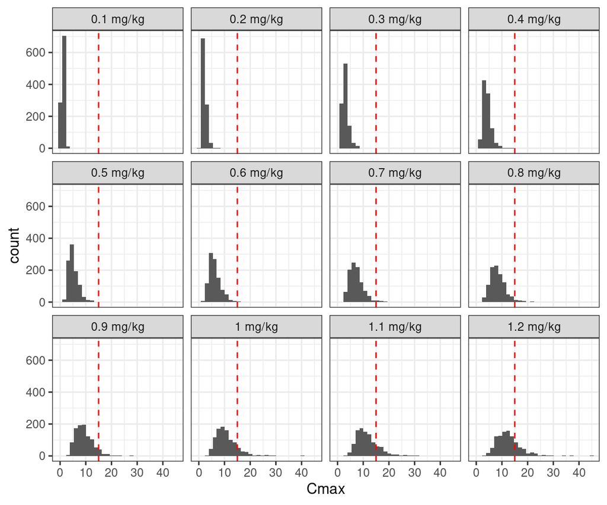

## Hands-on Session: Exercise 1 Cmax

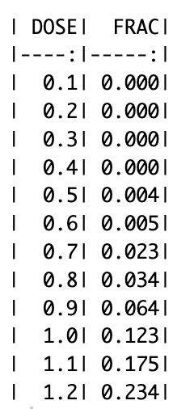

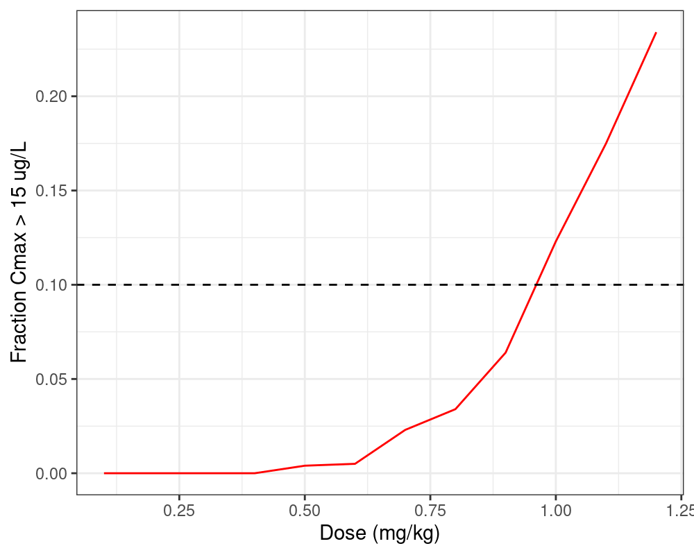

# Visual Predictive Checks (VPCs)

- Simulation-based diagnosis.
- Standard model diagnostics use residuals and other comparisons between observed and predicted values.
- Simulation-based diagnostics simulate from the model, and compare simulated data to observed data.
  - If a model is developed to adequately characterize the data, the model can produce which are similar to that used to fit (i.e., develop) it.

## Example model

```r
code <- '
  [ prob ]
    One-compartmental model + 0 and 1st order abs and 1st order elim
    Allometric scaling on CL and V patrameters
    Covariate-effects (SEX, AGE, ALB) on CL
    Proportional error model
    This model requires mrgsolve >= 1.0.3

  [ cmt ] depot cent

  [ input ]
    WT  = 70
    SEX = 1
    AGE = 35
    ALB = 4.5

  [ theta ]
    1.5    //  1 CL (L/hr) - 3.5
    5.0    //  2 V  (L) - 60
    0.5    //  3 KA (1/hr) - 1.5
    0.8    //  4 D1 (/hr) - 1.5
    0.7    //  5 SEX~CL (fractional multiplier)
    0.5    //  6 AGE~CL (exponent)
    0.2    //  7 ALB~CL (exponent)
    0.75   //  8 WT~CL (exponent)
    1.0    //  9 WT~CL (exponent)

  [ omega ] @correlation
    0.15             // ETA(CL)
    0.50 0.15        // ETA(V)
    0.10 0.20 0.1    // ETA(D1)

  [ sigma ]
    0.15              // Prop

    [ pk ]
    // Typical values of PK parameters
    double TVCL   = THETA(1);
    double TVV    = THETA(2);
    double TVKA   = THETA(3);
    double TVD1   = THETA(4);

    // PK covariates
    double CL_SEX = pow(THETA(5)  , SEX-1   );
    double CL_AGE = pow((AGE/35.0), THETA(6));
    double CL_ALB = pow((ALB/4.5) , THETA(7));
    double CL_WT  = pow((WT/70)   , THETA(8));
    double V_WT   = pow((WT/70)   , THETA(9));

    double CLCOV = CL_AGE*CL_WT;
    double VCOV  = V_WT;

    // PK parameters
    double CL = TVCL*CLCOV*exp(ETA(1));
    double V  = TVV*VCOV*exp(ETA(2));
    double KA = TVKA;
    double D1 = TVD1*exp(ETA(3));

    double S2 = V;

    D_depot = D1;

  [ ode ]
    dxdt_depot = -KA*depot;
    dxdt_cent = KA*depot - (CL/V)*cent;

  [ error ]
    double IPRED = cent/S2;
    double Y = IPRED * (1+EPS(1));

  [ capture ] CL V IPRED Y
  '

# Load model
mod <- mcode("example", code)
```

```r
see(mod)
```

```
Model file:  example.cpp

  [ prob ]
    One-compartmental model + 0 and 1st order abs and 1st order elim
    Allometric scaling on CL and V patrameters
    Covariate-effects (SEX, AGE, ALB) on CL
    Proportional error model
    This model requires mrgsolve >= 1.0.3

  [ cmt ] depot cent

  [ input ]
    WT  = 70
    SEX = 1
    AGE = 35
    ALB = 4.5

  [ theta ]
    1.5    //  1 CL (L/hr) - 3.5
    5.0    //  2 V  (L) - 60
    0.5    //  3 KA (1/hr) - 1.5
    0.8    //  4 D1 (/hr) - 1.5
    0.7    //  5 SEX~CL (fractional multiplier)
    0.5    //  6 AGE~CL (exponent)
    0.2    //  7 ALB~CL (exponent)
    0.75   //  8 WT~CL (exponent)
    1.0    //  9 WT~CL (exponent)

  [ omega ] @correlation
    0.15             // ETA(CL)
    0.50 0.15        // ETA(V)
    0.10 0.20 0.1    // ETA(D1)

  [ sigma ]
    0.15              // Prop

    [ pk ]
    // Typical values of PK parameters
    double TVCL   = THETA(1);
    double TVV    = THETA(2);
```

[output cut: 17 more lines]

```
    double D1 = TVD1*exp(ETA(3));

    double S2 = V;

    D_depot = D1;

  [ ode ]
    dxdt_depot = -KA*depot;
    dxdt_cent = KA*depot - (CL/V)*cent;

  [ error ]
    double IPRED = cent/S2;
    double Y = IPRED * (1+EPS(1));

  [ capture ] CL V IPRED Y
```

## Example data

```r
head(data)
```

```
  C NUM ID   TIME NTIME   TAD AMT CMT EVID II ADDL    DV BLQ LLOQ DOSE AGE SEX
1 .   1 51   0.00 120.1  0.00 200   1    1 24    6  0.00   0  0.1  200  18   2
2 .   2 51 120.09 120.1  0.09   0   2    0  0    0  5.57   0  0.1  200  18   2
3 .   3 51 121.04 121.0  1.04   0   2    0  0    0 15.43   0  0.1  200  18   2
4 .   4 51 124.07 124.0  4.07   0   2    0  0    0 33.57   0  0.1  200  18   2
5 .   5 51 128.24 128.0  8.24   0   2    0  0    0 20.59   0  0.1  200  18   2
6 .   6 51 139.22 140.0 19.22   0   2    0  0    0  0.99   0  0.1  200  18   2
  RACE ALB  SCR   WT    HT
1    3 4.4 0.72 56.9 160.7
2    3 4.4 0.72 56.9 160.7
3    3 4.4 0.72 56.9 160.7
4    3 4.4 0.72 56.9 160.7
5    3 4.4 0.72 56.9 160.7
6    3 4.4 0.72 56.9 160.7
```

## Example data

Plot data.

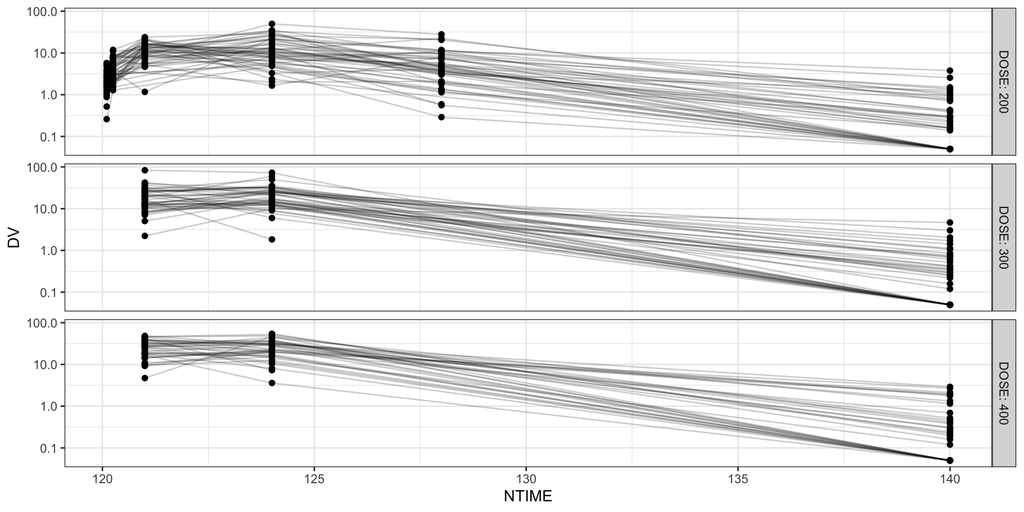

```r
filter(data, EVID==0) %>%
  ggplot(aes(x=NTIME, y=DV, group=ID))+
  geom_point()+geom_line(alpha=0.2)+
  facet_grid(rows=vars(DOSE),
             labeller=label_both)+
  scale_y_log10()
```

There are three dose group: the lower dose group 200 has relatively intensive sampling, and the higher dose group has relatively sparse sampling. Let’s check the number of subjects per dose group.

```r
data %>% distinct(ID, .keep_all=TRUE) %>%
  count(DOSE)
```

```
  DOSE  n
1  200 50
2  300 50
3  400 50
```

## Simulation and comparison?

```r
# Subset
data_200 <- filter(data, DOSE==200)

# Simulation 1 (Single simulation)
inventory(mod, data)

withr::with_seed(
  seed=123,
  sim <- mrgsim_df(mod, data_200, obsonly=TRUE, recover="DV,NTIME,DOSE")
  )

obs <- data_200 %>% filter(EVID==0)

p1 <- raw_pk_plot(obs)+ggtitle("Observed")+scale_y_log10(limits = c(0.0001, 1000))
p2 <- raw_pk_plot(sim, .y=Y)+ggtitle("Simulated")+scale_y_log10(limits = c(0.0001, 1000))
grid.arrange(p1, p2, ncol=2)
```

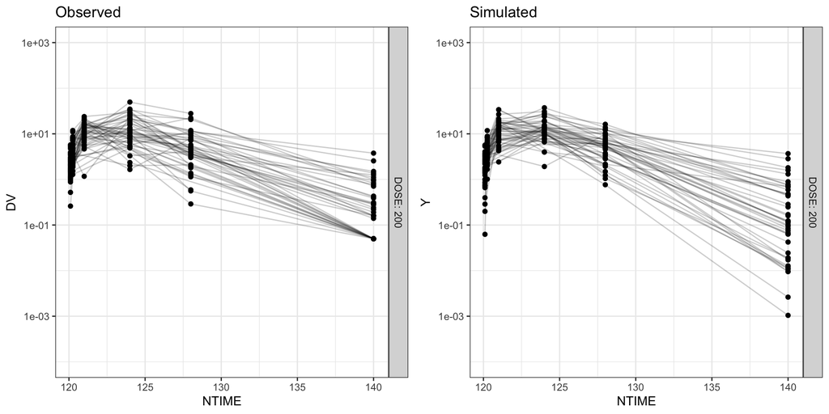

## Another way?

```r
p1 <- summ_pk_plot(sim, .y=Y, show_obs=TRUE)
p1
```

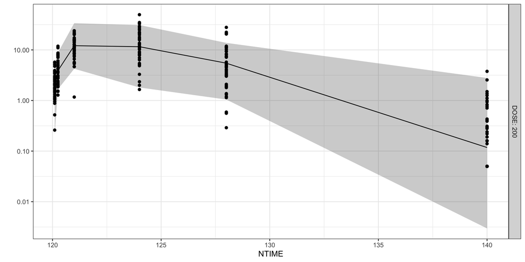

## Simulation reply on 1 replicate is risky

However, we may not reply on one **stochastic** simulation to evaluate the model performance. If we simulate using the same settings for a second time, it will look different compared to the first simulation.

```r
withr::with_seed(
  seed=321,
  sim2 <- mrgsim_df(mod, data_200, obsonly=TRUE, recover="DV,NTIME,DOSE")
  )
p2 <- summ_pk_plot(sim2, .y=Y, show_obs=TRUE)
grid.arrange(p1, p2, ncol=2)
```

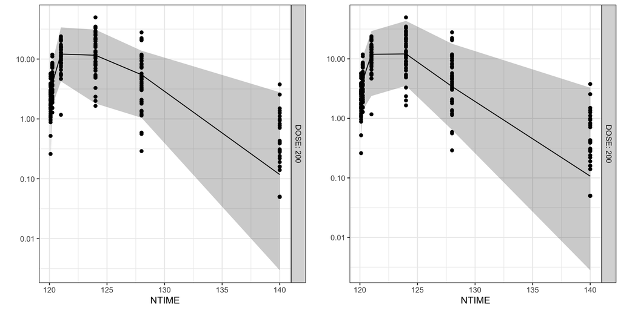

## Simulation with replicates

Therefore, we need to simulate with replicates (e.g., n=100) to evaluate the totality of the stochastic simulations.

```r
rep <- 100

withr::with_seed(seed=1314,
                 sim <- purrr::map(1:rep, function(.irep){
                   mrgsim_df(mod, data_200, obsonly=TRUE, recover="DV,NTIME,DOSE") %>%
                  mutate(IREP=.irep)
                   }) %>% bind_rows()
                 )
```

## Simulation with replicates

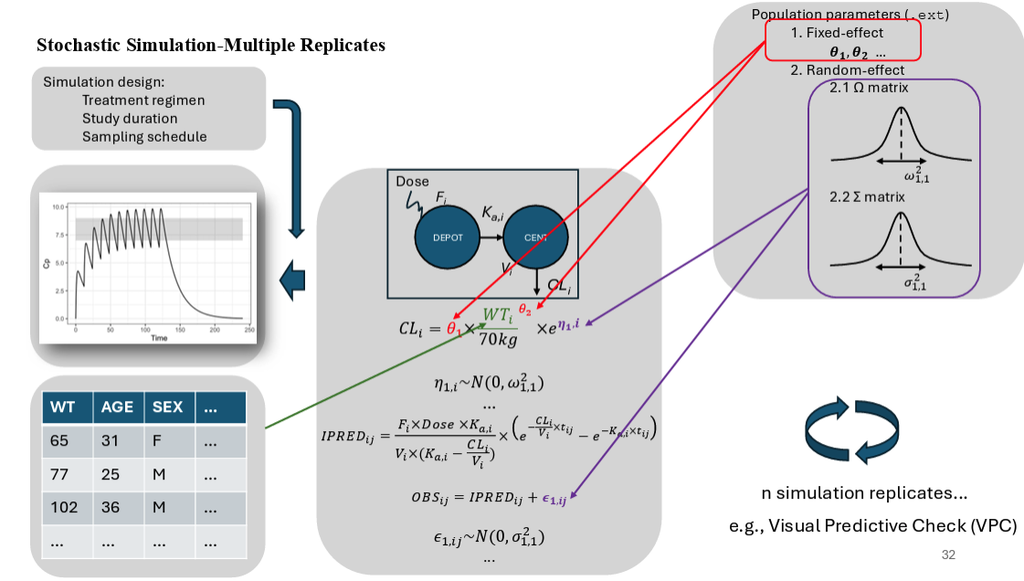

## Simulation with replicates

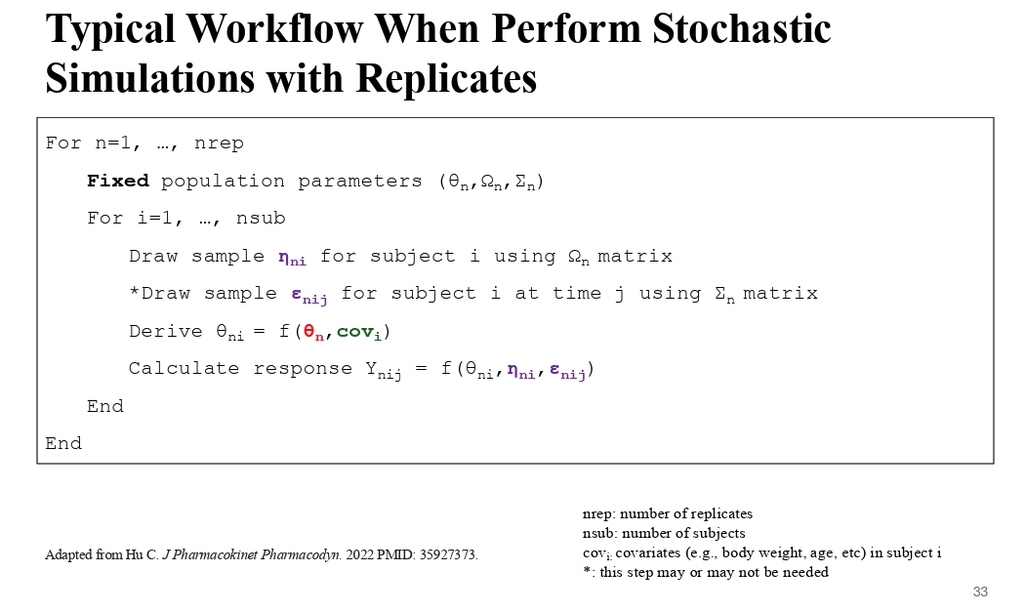

## But then how we should effectively visualize it?

```r
p1 <- sim %>% filter(IREP<10) %>%
  summ_pk_plot(., .y=Y, show_obs=TRUE)+
  facet_wrap(~IREP)
p1
```

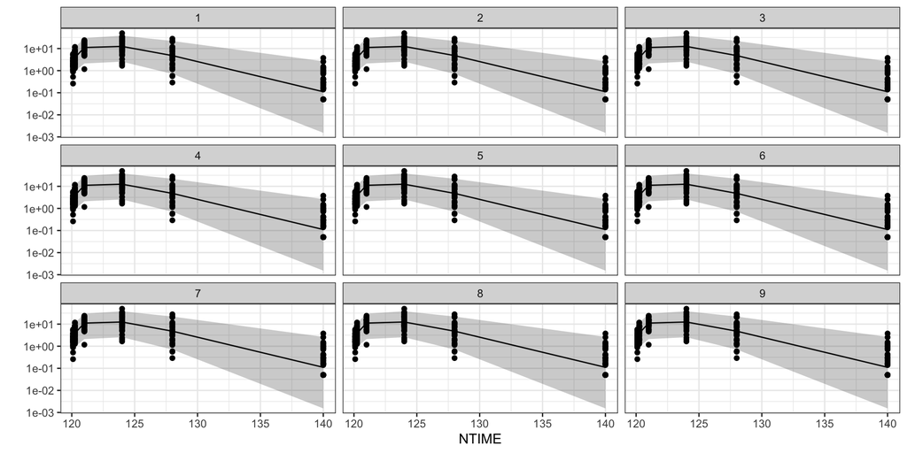

## VPC: Observations

- For observed PK profiles, we will summarize:
  - 10th percentile.
  - 50th percentile.
  - 90th percentile.

## VPC: Simulations

- For simulated PK profiles, we will summarize:
  - 10th percentile of 10th percentiles across simulation replicates.
  - 50th percentile of 10th percentiles across simulation replicates.
  - 90th percentile of 10th percentiles across simulation replicates.
  - 10th percentile of 50th percentiles across simulation replicates.
  - 50th percentile of 50th percentiles across simulation replicates.
  - 90th percentile of 50th percentiles across simulation replicates.
  - 10th percentile of 90th percentiles across simulation replicates.
  - 50th percentile of 90th percentiles across simulation replicates.
  - 90th percentile of 90th percentiles across simulation replicates.

## An example VPC

```r
percentile <- c(0.10, 0.50, 0.90) # Percentiles for visualization
prob       <- c(0.10, 0.50, 0.90) # %PI for percentiles

# Summarise observed percentiles
summ_obs <- obs %>%
  filter(BLQ==0) %>%
  group_by(NTIME, DOSE) %>%
  summarise(
    as_tibble_row(
      quantile(DV, percentile,na.rm = TRUE),
      .name_repair= ~ c("lo", "mi", "hi")
      ), .groups = "drop")

# Summarise simulated percentiles
summ_sim <- sim %>%  filter(Y>=unique(obs$LLOQ)) %>%
  group_by(NTIME, DOSE, IREP) %>%
    summarise(
      as_tibble_row(
        quantile(Y, percentile,na.rm = TRUE),
        .name_repair= ~ c("lo", "mi", "hi")
      ), .groups = "drop")

# Summarise prediction intervals of simulated percentiles
summ_sim <- summ_sim %>% group_by(NTIME, DOSE) %>%
  summarise(
    across(c("lo", "mi", "hi"),
           ~ list(setNames(
             quantile(.x, prob, na.rm = TRUE),
             c("lo", "mi", "hi")
             ))), .groups = "drop") %>%
    # widen each list-column (one per Y) into 3 numeric columns
  unnest_wider(c("lo", "mi", "hi"), names_sep = "_")

# head(obs)
# head(sim)

vpc <- ggplot()+
    geom_line(data=summ_obs, aes(x=NTIME, y=lo), linetype=2)+
    geom_line(data=summ_obs, aes(x=NTIME, y=mi), linetype=1)+
    geom_line(data=summ_obs, aes(x=NTIME, y=hi), linetype=2)+
    geom_ribbon(data=summ_sim, aes(x=NTIME, ymin=lo_lo, ymax=lo_hi), alpha=0.25, fill="#ffcc33")+
    geom_ribbon(data=summ_sim, aes(x=NTIME, ymin=mi_lo, ymax=mi_hi), alpha=0.25, fill="#7A0019")+
    geom_ribbon(data=summ_sim, aes(x=NTIME, ymin=hi_lo, ymax=hi_hi), alpha=0.25, fill="#ffcc33")+
    facet_grid(vars(DOSE), labeller=label_both)+
  scale_y_log10()+
  xlab("Time")+
  ylab("Concentrations")+
  ggtitle("Visual Predictive Checks (VPC)")
vpc
```

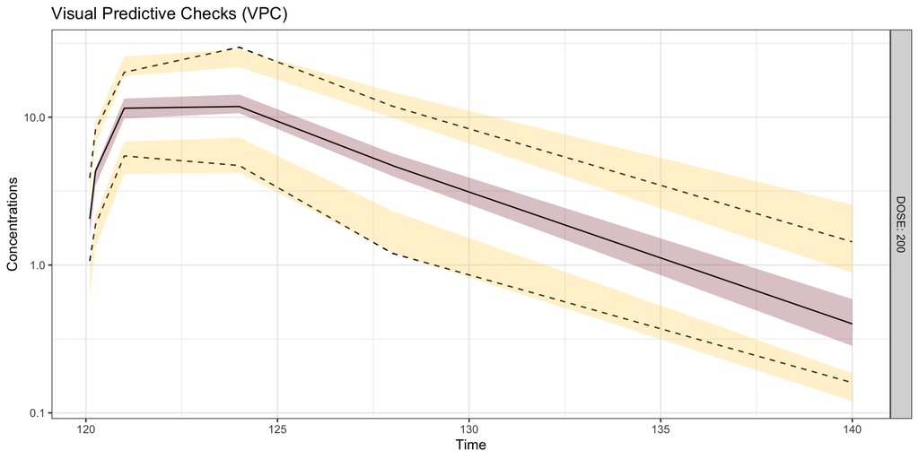

## An example VPC

We frequently see VPCs with observed concentrations shown as dots, but this is not something required for diagnostic purposes.

```r
vpc + geom_point(data=filter(obs, BLQ==0), aes(x=NTIME, y=DV))
```

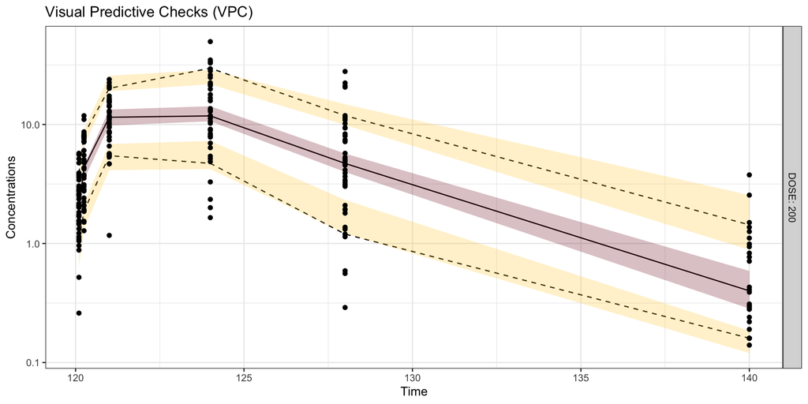

## Binning

If you have worked on creating VPCs before, an tedious (or somewhat annoying) issue is binning. Why bothering with it?

- In reality, we usually develop model using **actual time** instead of **nominal time**.
- This makes the summarization of the percentiles across time become challenging.

## Binning

```r
p1  <- raw_pk_plot(obs, .x=NTIME)+ggtitle("Nominal time")
p2  <- raw_pk_plot(obs, .x=TIME)+ggtitle("Actual time")
p3 <- vpcplot(obs_df=filter(obs, BLQ==0),
              sim_df=filter(sim, Y>unique(obs$LLOQ)),
              .x=NTIME, show_obs = TRUE, .xlab = "Time", .ylab = "Concentrations")+
  ggtitle("VPC using nominal time")
p4 <- vpcplot(obs_df=filter(obs, BLQ==0),
              sim_df=filter(sim, Y>unique(obs$LLOQ)),
              .x=TIME, show_obs = TRUE, .xlab = "Time", .ylab = "Concentrations")+
  ggtitle("VPC using actual time")
grid.arrange(p1,p2,p3,p4,ncol=2)
```

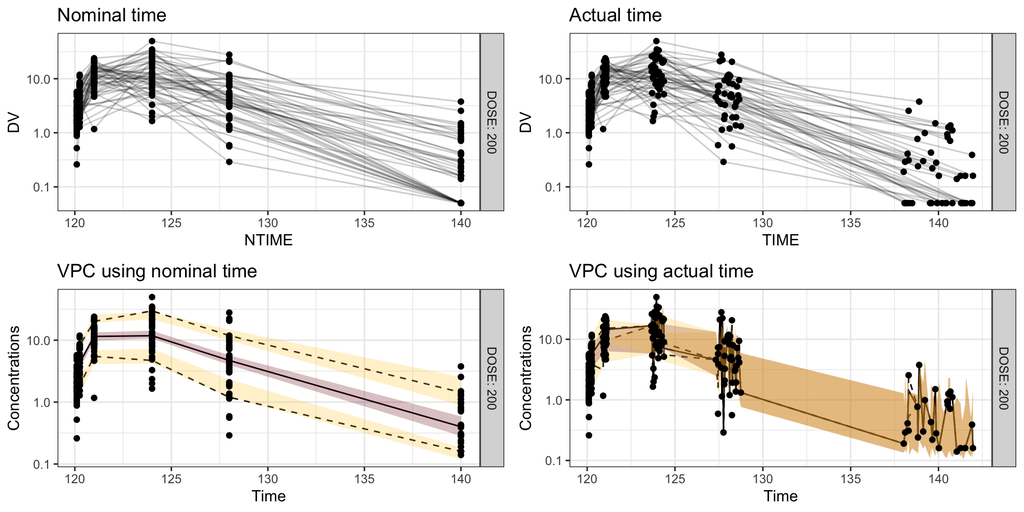

## Binning

- As we created VPCs using actual time without binning, the plot (bottom right) looks messy, losing diagnostic values.
- This is why we want to bin observations based on time intervals when creating VPCs plots.
- Essentially, this step classifies actual time into time intervals/bins (i.e., binning), and then summarize observations via grouping by time bins instead of actual times.

## VPC after Binning

```r
vpcplot(obs_df=filter(obs, BLQ==0),
        sim_df=filter(sim, Y>unique(obs$LLOQ)),
        .x=TIME, show_obs = TRUE,
        .xlab = "Time", .ylab = "Concentrations",
        bins = c(119, 120.15, 120.5, 122, 126, 130, 150))
```

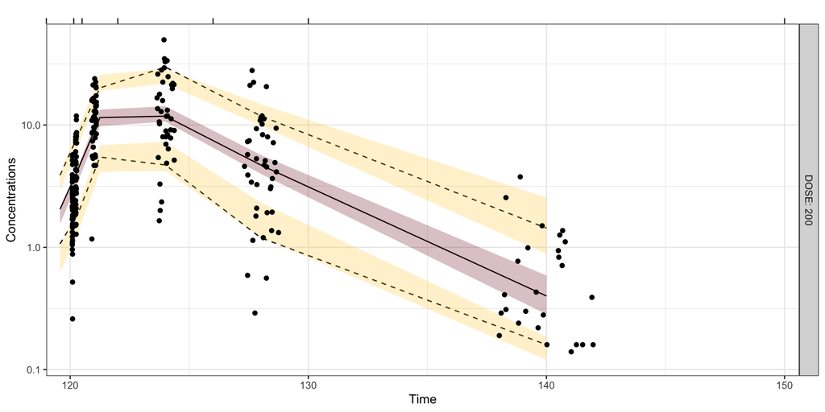

## VPC in reality

```r
rep <- 100

withr::with_seed(seed=1314,
                 sim <- purrr::map(1:rep, function(.irep){
                   mrgsim_df(mod, data_200, obsonly=TRUE, recover="DV,NTIME,DOSE") %>%
                  mutate(IREP=.irep)
                   }) %>% bind_rows()
                 )
```

```r
library(vpc)

vpc(sim=filter(sim, Y>unique(obs$LLOQ)),
    obs=filter(obs, BLQ==0),
    obs_cols=list(idv="TIME"),
    sim_cols=list(idv="TIME", dv="Y"),
    bins=c(119, 120.15, 120.5, 122, 126, 130, 150),
    show=list(obs_dv=TRUE),
    log_y=TRUE,
    log_y_min=0.1)
```

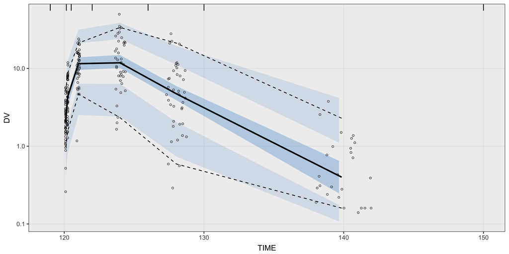

## VPC in reality

```r
library(tidyvpc)

obs_data <- as.data.frame(filter(obs, BLQ==0))
sim_data <- as.data.frame(filter(sim, Y>unique(obs$LLOQ)))

vpc <- observed(obs_data, x=TIME, y=DV) %>%
  simulated(sim_data, xsim=TIME, ysim=Y, repl=IREP) %>%
  binning(bin="breaks", breaks = c(119, 120.15, 120.5, 122, 126, 130, 150))%>%
  vpcstats()
plot(vpc) + scale_y_log10(labels = scales::label_log())
```

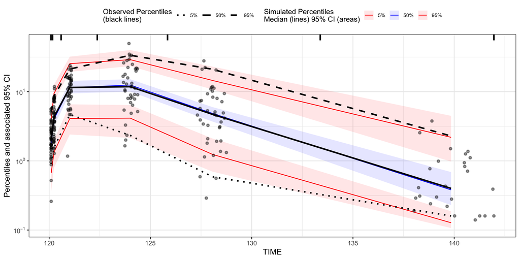

## VPC variants

- Landmark VPCs:

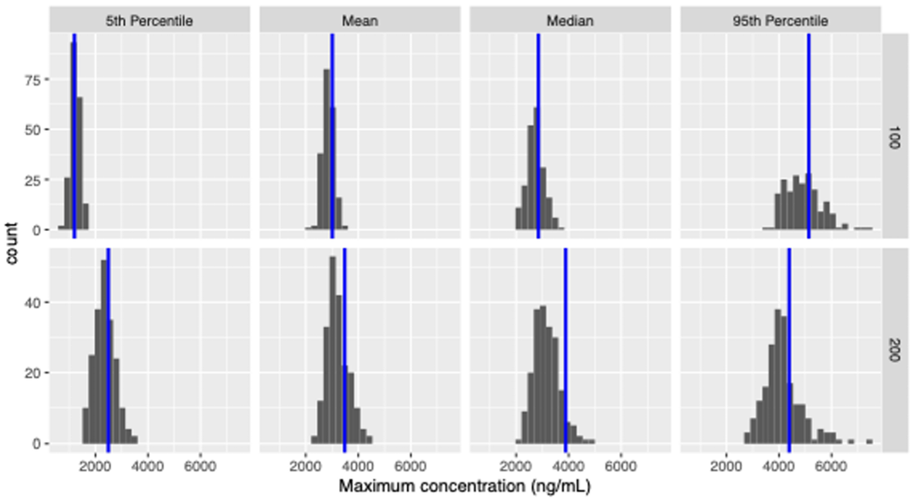

- Prediction-corrected VPCs (pcVPCs): M. Bergstrand, et al., AAPS J
- Reference-corrected VPCs (rcVPCs): [M. Ibrahim, et al., AAPS J 2025](https://www.ncbi.nlm.nih.gov/pubmed/40299161)